# Master file Analysis

2020-06-10

#### 0.0.0.1 Document History

Original Publish Date: 10 June, 2020

Updated on: 11:06 AM – 04 June, 2021

In this project we are using a novel dataset compiled by Rahul Verma. This dataset covers the candidates contested in the different levels of elections held from 1974 to 2019 in the state of Uttar Pradesh. This includes assembly, general and local body elections. This dataset connects the contestants to the political offices to their family members within that universe.

We define dynast politicians as those who are preceded by family members who are currently active in politics or were active in the past. Family is defined as a set of individuals who are bound by proximate ties based on blood or marriage, and this definition includes father, mother, grand parents, siblings and in laws. Active in politics refers to holding an office in an elected body or being a candidate in elections. According to this definition, the head of family or the patriarch is considered to be a non-dynast in the year of entry. Precisely, because of the fact that he did not enjoy any advantage of having family members in politics at that point of time. But, ones a family member enter into the universe of politics, in later years patriarch will be considered as dynast along with the descendants.Additionally, both the first and second member should be entered to the system through assembly or general elections

We have come up with different definitions for dynasties that are specific to this contest. They are as follows.

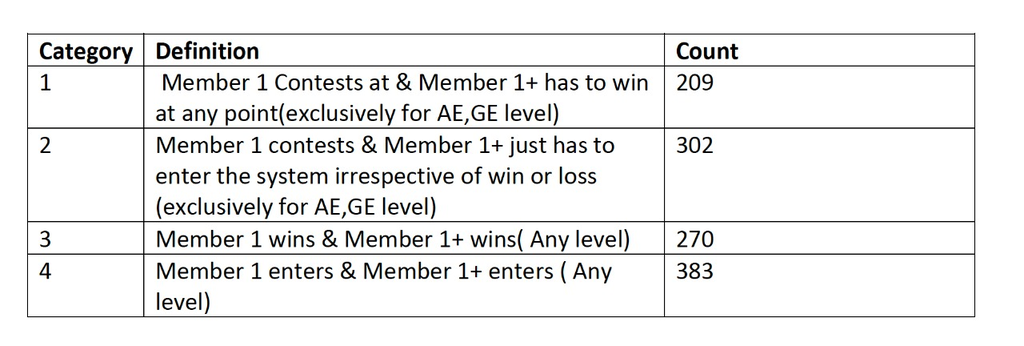

For the purpose of this analysis we will be using the second definition.

## 0.1 Summary statistics

**Entries from different levels**

### 0.1.1 Local body

The dynasty dataset includes winners from local body elections for all the local body institutions except GP - Block Panchayats, Zilla Panchayats , Nagar Panchayts and Nagar Nigams from the year 1995.

| Urban/Rural | Local body | Observations |
| --- | --- | --- |
| Urban local body | Nagar Nigam | 60 |
| Urban local body | Nagar Palika Parishad | 970 |
| Urban locla body | Nagar Panchayat | 2105 |
| Rural local body | Zilla Panchayat | 339 |
| Rural local body | Block Panchayat | 3932 |

### 0.1.2 AE - GE

- Total observations: 11550
- AE observations :9650
- AE unique observations :4603
- GE observations :1900
- GE unique observations :1022
- Number of unique individuals: 5276
- Number of unique families : 322

#### 0.1.2.1 Maps

##### 0.1.2.1.1 AC

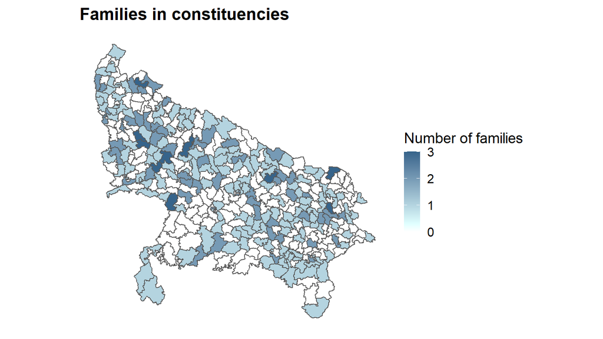

##### 0.1.2.1.2 PC

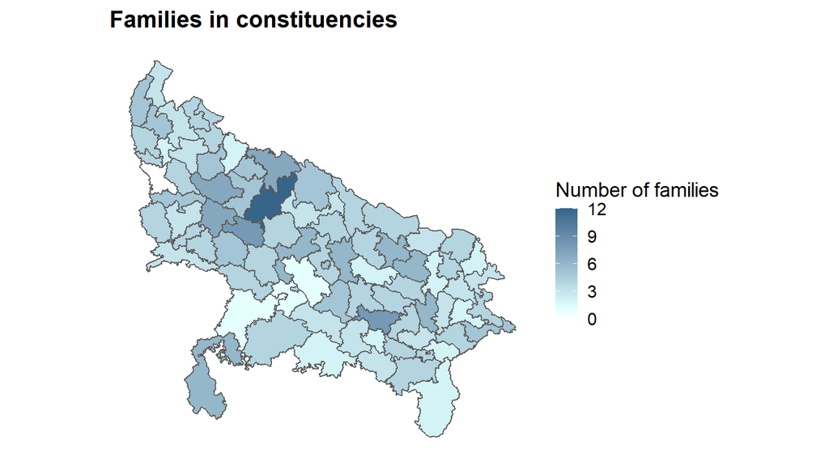

The following section provides the year and election level wise break-up of the observations

#### 0.1.2.2 obs. break-up

##### 0.1.2.2.1 Assembly Elections

| Year | Count |
| --- | --- |
| 1974 | 804 |
| 1977 | 806 |
| 1980 | 806 |
| 1985 | 806 |
| 1989 | 806 |
| 1991 | 794 |
| 1993 | 800 |
| 1996 | 804 |
| 2002 | 806 |
| 2007 | 806 |
| 2012 | 806 |
| 2017 | 806 |

##### 0.1.2.2.2 General Elections

| Year | Count |
| --- | --- |
| 1977 | 158 |
| 1980 | 158 |
| 1984 | 158 |
| 1989 | 158 |
| 1991 | 156 |
| 1996 | 158 |
| 1998 | 158 |
| 1999 | 158 |
| 2004 | 158 |
| 2009 | 160 |
| 2014 | 160 |
| 2019 | 160 |

### 0.1.3 Levels

#### 0.1.3.1 def 2

Linkages of families(Category 2)

| level | count |
| --- | --- |
| AE | 155 |
| GE-AE | 108 |
| GE-AE-LB | 23 |
| AE-LB | 22 |
| GE | 14 |

#### 0.1.3.2 def 4

Linkages of families(Category 4)

| level | count |
| --- | --- |
| LB | 719 |
| AE | 155 |
| GE-AE | 108 |
| AE-LB | 103 |
| GE-AE-LB | 33 |
| GE | 14 |
| GE-LB | 6 |

## 0.2 Past elections

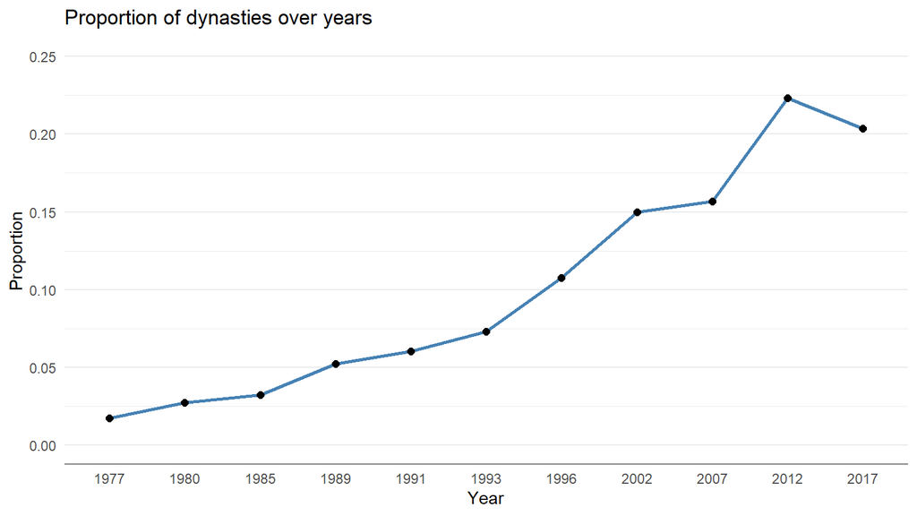

## 0.3 Entry year

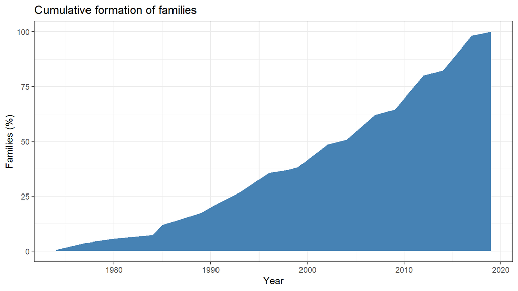

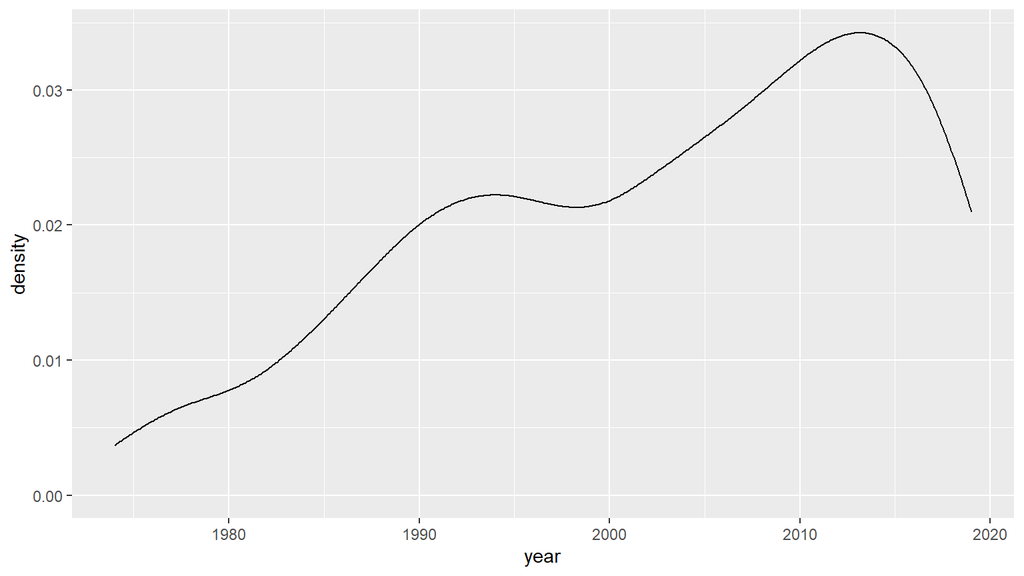

## 0.4 caste

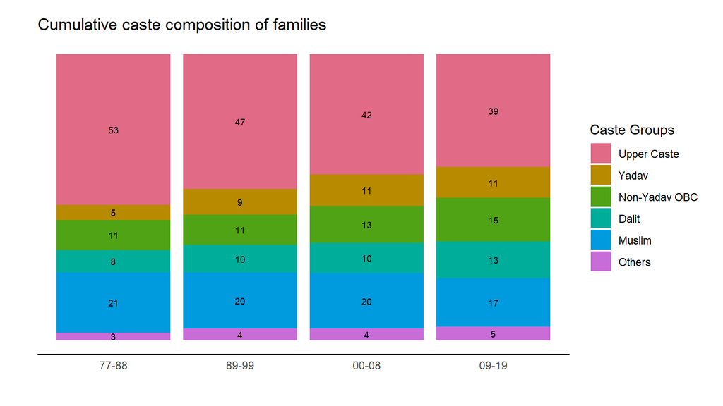

## 0.5 AE GE election contest

There could four types of election contests:

- Dynast wins against against a Dynast
- Dynast wins against a Non-dynast
- Non-dynast wins against another Non-dynast
- Non-dynast wins against a dynast

First table shows count of the contests and the second one shows the proportion of contests. First part represents the winner in both the tables headers.

### 0.5.1 Count

| election_id | fam v/s fam | fam v/s non-fam | non-fam v/s fam | non-fam v/s non-fam |
| --- | --- | --- | --- | --- |
| AE1977 | NA | 7 | 4 | 392 |
| AE1980 | NA | 11 | 5 | 387 |
| AE1985 | 1 | 12 | 13 | 377 |
| AE1989 | 2 | 19 | 16 | 366 |
| AE1991 | 2 | 22 | 17 | 356 |
| AE1993 | 1 | 28 | 17 | 354 |
| AE1996 | 4 | 39 | 23 | 336 |
| AE2002 | 15 | 45 | 28 | 315 |
| AE2007 | 12 | 52 | 51 | 288 |
| AE2012 | 23 | 67 | 47 | 266 |
| AE2017 | 12 | 70 | 81 | 240 |
| GE1977 | 1 | 2 | 3 | 73 |
| GE1980 | NA | 4 | 3 | 72 |
| GE1984 | 1 | 6 | 2 | 70 |
| GE1989 | NA | 10 | 8 | 61 |
| GE1991 | 1 | 7 | 6 | 64 |
| GE1996 | 2 | 12 | 6 | 59 |
| GE1998 | 5 | 8 | 10 | 56 |
| GE1999 | 6 | 15 | 5 | 53 |
| GE2004 | 6 | 19 | 8 | 46 |
| GE2009 | 6 | 28 | 10 | 36 |
| GE2014 | 6 | 17 | 20 | 37 |
| GE2019 | 4 | 24 | 18 | 34 |

### 0.5.2 Percentage

| election_id | fam v/s fam | fam v/s non-fam | non-fam v/s fam | non-fam v/s non-fam |
| --- | --- | --- | --- | --- |
| AE1977 | NA | 0.02 | 0.01 | 0.97 |
| AE1980 | NA | 0.03 | 0.01 | 0.96 |
| AE1985 | 0.00 | 0.03 | 0.03 | 0.94 |
| AE1989 | 0.00 | 0.05 | 0.04 | 0.91 |
| AE1991 | 0.01 | 0.06 | 0.04 | 0.90 |
| AE1993 | 0.00 | 0.07 | 0.04 | 0.88 |
| AE1996 | 0.01 | 0.10 | 0.06 | 0.84 |
| AE2002 | 0.04 | 0.11 | 0.07 | 0.78 |
| AE2007 | 0.03 | 0.13 | 0.13 | 0.71 |
| AE2012 | 0.06 | 0.17 | 0.12 | 0.66 |
| AE2017 | 0.03 | 0.17 | 0.20 | 0.60 |
| GE1977 | 0.01 | 0.03 | 0.04 | 0.92 |
| GE1980 | NA | 0.05 | 0.04 | 0.91 |
| GE1984 | 0.01 | 0.08 | 0.03 | 0.89 |
| GE1989 | NA | 0.13 | 0.10 | 0.77 |
| GE1991 | 0.01 | 0.09 | 0.08 | 0.82 |
| GE1996 | 0.03 | 0.15 | 0.08 | 0.75 |
| GE1998 | 0.06 | 0.10 | 0.13 | 0.71 |
| GE1999 | 0.08 | 0.19 | 0.06 | 0.67 |
| GE2004 | 0.08 | 0.24 | 0.10 | 0.58 |
| GE2009 | 0.07 | 0.35 | 0.12 | 0.45 |
| GE2014 | 0.07 | 0.21 | 0.25 | 0.46 |
| GE2019 | 0.05 | 0.30 | 0.22 | 0.42 |

## 0.6 seats contested by dynasts

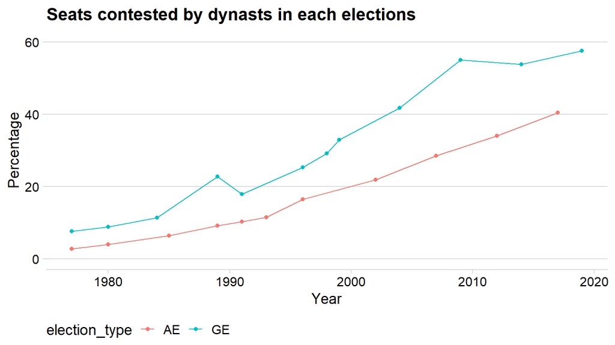

## 0.7 Election contested

```
##
##    1    2    3    4    5    6    7    8    9   10   11   12   13
## 2495  925  459  265  170   97   66   37   13   11    2    3    2
```

```
##
##    0    1    2    3    4    5    6    7    8    9   10
## 1910 1637  544  242  129   43   23   10    4    2    1
```

## 0.8 Elections won

### 0.8.1 table -individuals

This table shows the count of the unique individuals with regards to the number of elections they have **won**

Break-up of unique individuals wrt to elections won

| n_elections_won | n_individuals |
| --- | --- |
| 0 | 2082 |
| 1 | 1881 |
| 2 | 665 |
| 3 | 327 |
| 4 | 177 |
| 5 | 74 |
| 6 | 35 |
| 7 | 13 |
| 8 | 13 |
| 9 | 6 |
| 10 | 2 |
| 15 | 1 |

### 0.8.2 treemap - individuals

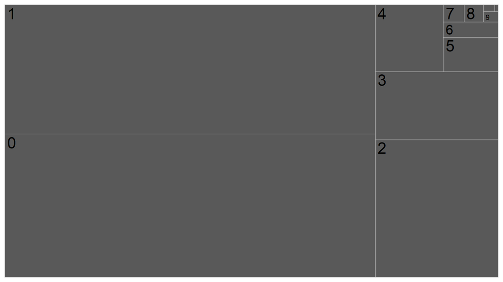

### 0.8.3 Density map of N elections won by families

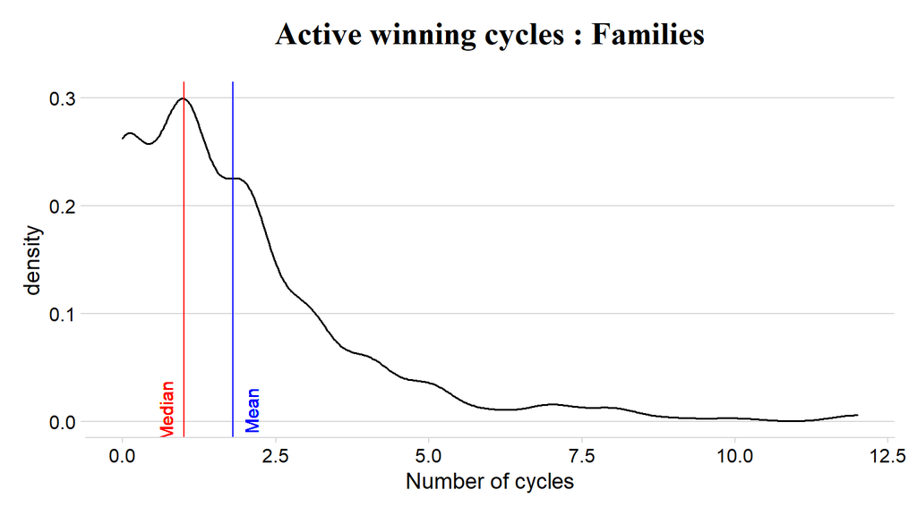

#### 0.8.3.1 Both - contested and won

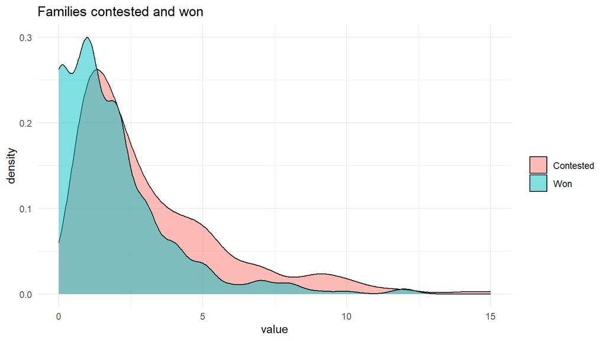

## 0.9 Elections contested

### 0.9.1 Table - individuals

This table shows the count of the unique individuals with regards to the number of elections they have **contested** .

Break-up of unique individuals wrt to elections contested

| n_elections_contested | n_individuals |
| --- | --- |
| 1 | 2753 |
| 2 | 1061 |
| 3 | 552 |
| 4 | 336 |
| 5 | 253 |
| 6 | 124 |
| 7 | 82 |
| 8 | 58 |
| 9 | 27 |
| 10 | 12 |
| 11 | 4 |
| 12 | 6 |
| 13 | 6 |
| 15 | 1 |
| 16 | 1 |

### 0.9.2 Density chart of election contested by families

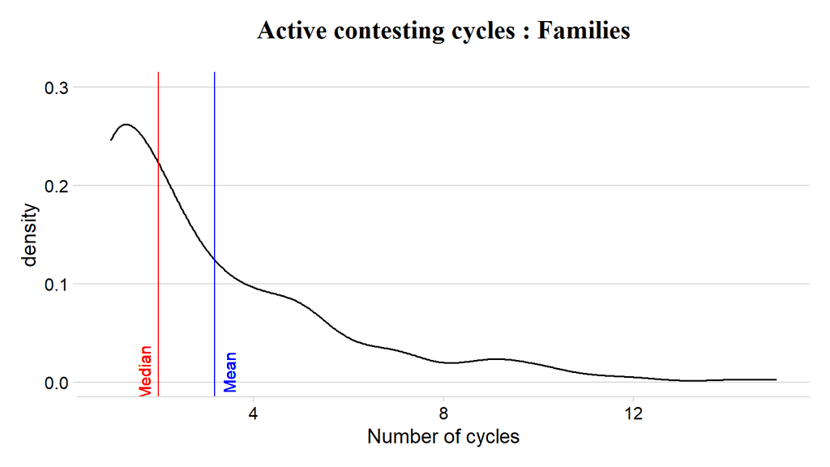

## 0.10 Strike rate

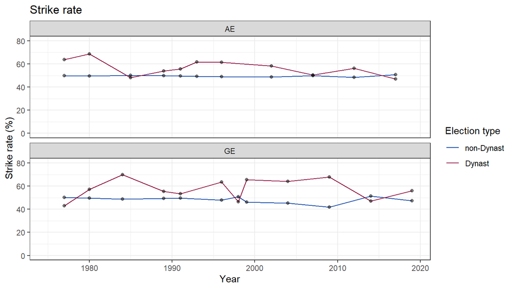

## 0.11 Life span

### 0.11.1 family

#### 0.11.1.1 1

Here life span is calculated by computing the difference in entry year of the family with the last appearance of a member from the same family. Life span is simply the longitudinal life of a family. This is calculated by simply computing the difference in the entry year of a family with the year in which the last member has contested. The following graph is a density chart of the the life span of the unique families in the dataset.

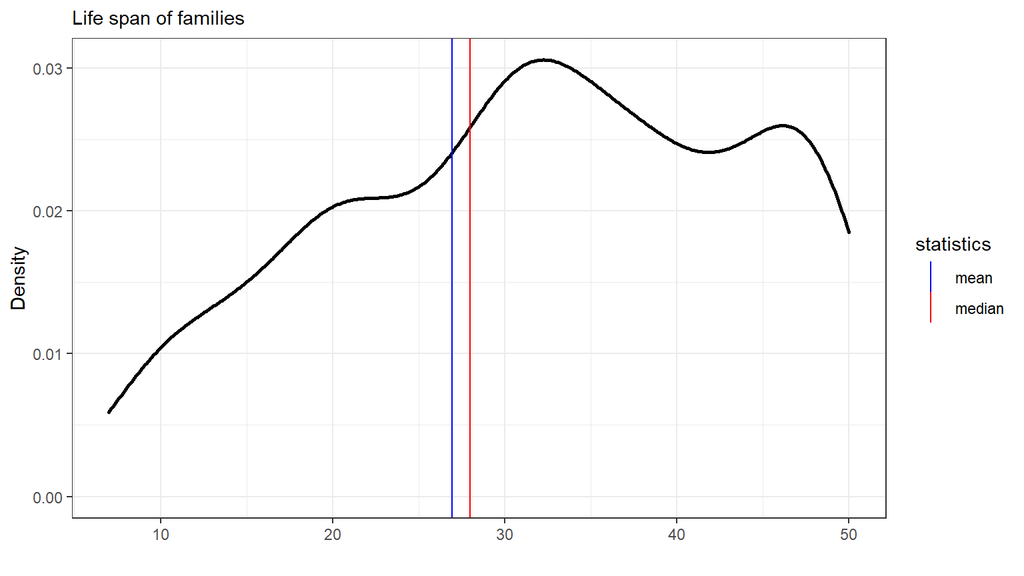

#### 0.11.1.2 2

Life span in this context is the year difference between the election that the patriarch contested before the second member and the last election that contested by someone from the family.

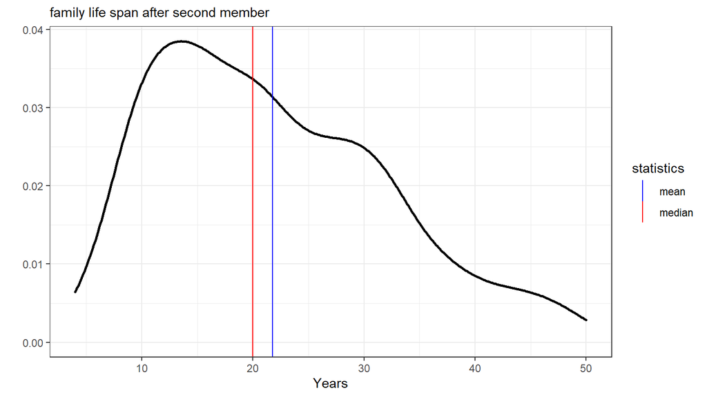

### 0.11.2 Individuals won

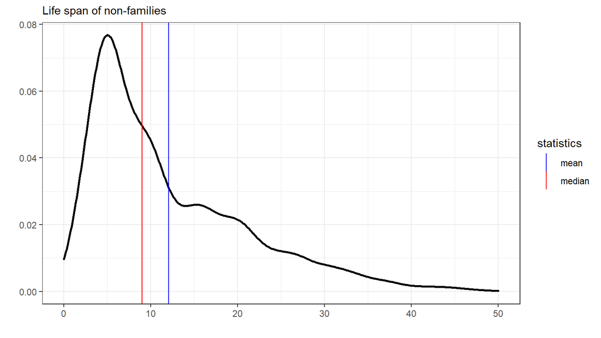

[figure not shown]

### 0.11.3 Individual life span

life span in this context is the the year diffrence between the first and last election the candidate has appeared.

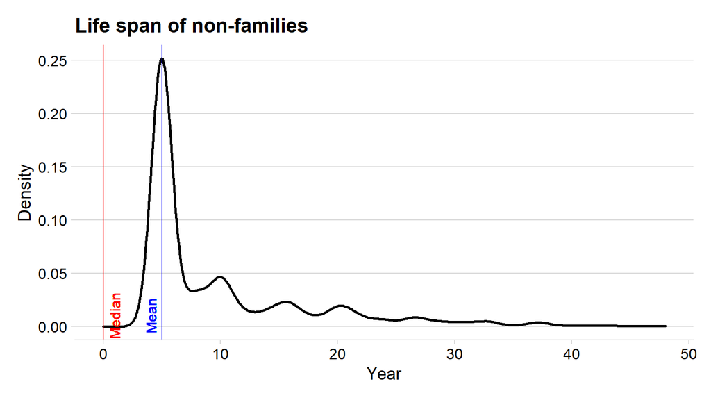

## 0.12 Experience

### 0.12.1 Family

This variable takes into year that ruled by a dynast ruler

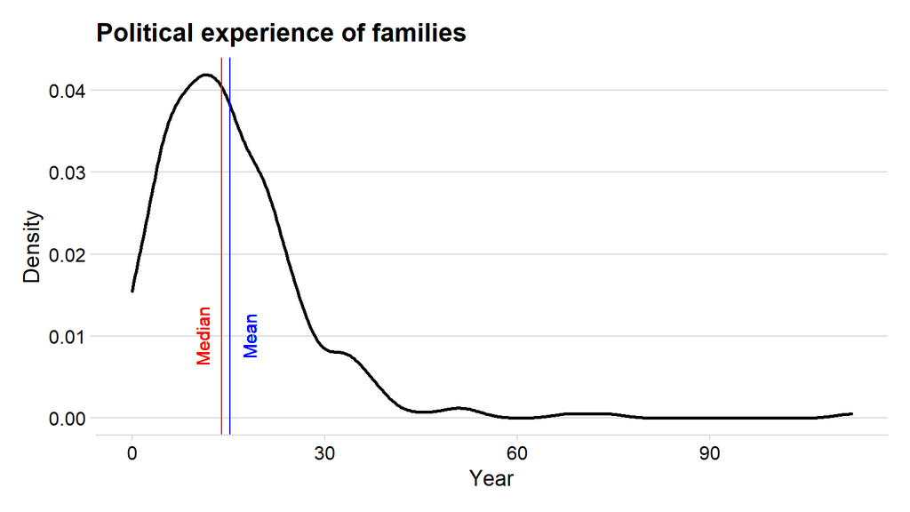

### 0.12.2 non-families

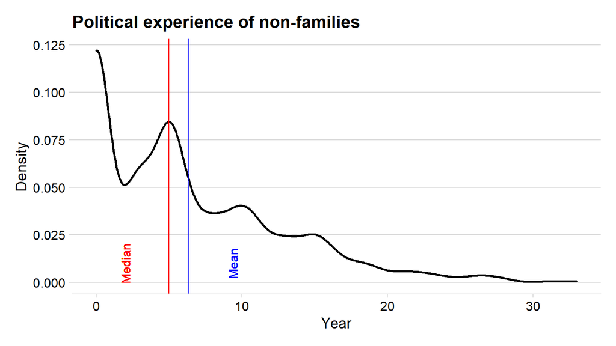

## 0.13 Retention

This chart depicts the retention of candidates after each election year.

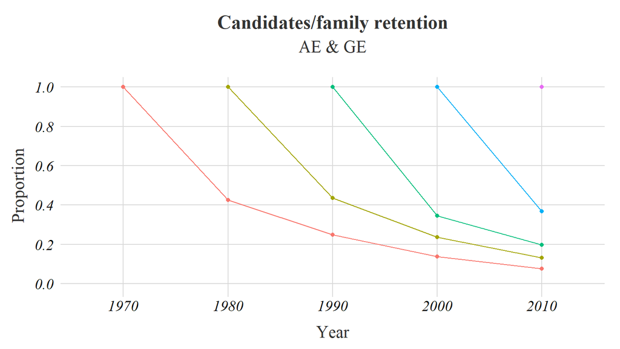

## 0.14 Land distribution

The dataset contains a variable named land which records the land owned by the candidate/family. The information is recorded in *bhigas*.

### 0.14.1 Families

This boxplot shows the difference the land owned by family and a non-family entity.

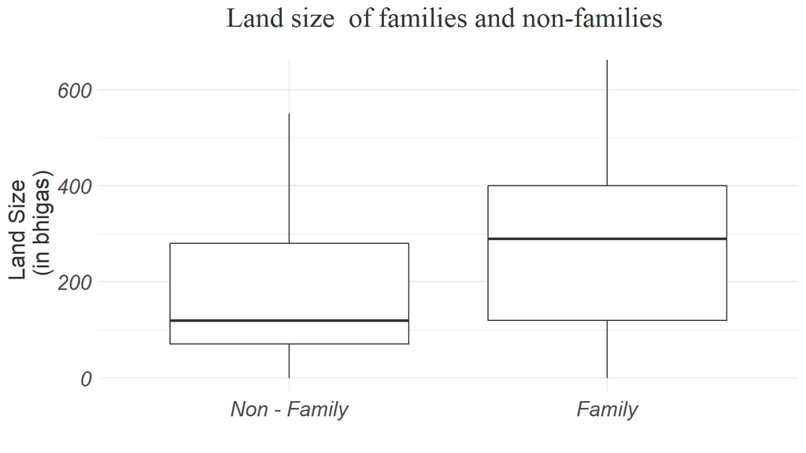

### 0.14.2 Political Experience

This boxplot shows the difference in the land ownership according to a candidate’s political experience. Political experience is the sum of term duration of every election that they have won.

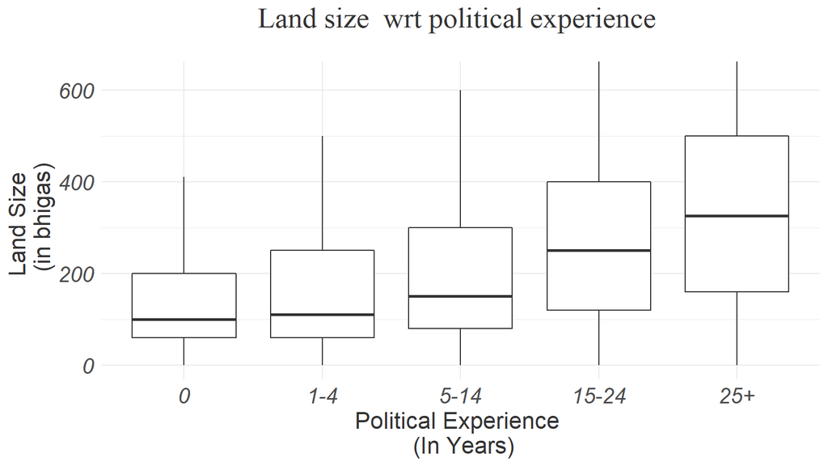

## 0.15 Educational institutions

The data set has variable which record the candidate’s/ family’s ownership of school/college/both.

### 0.15.1 Families

This barplot depicts the difference in the ownership of educational institutions among family and non-family entities.

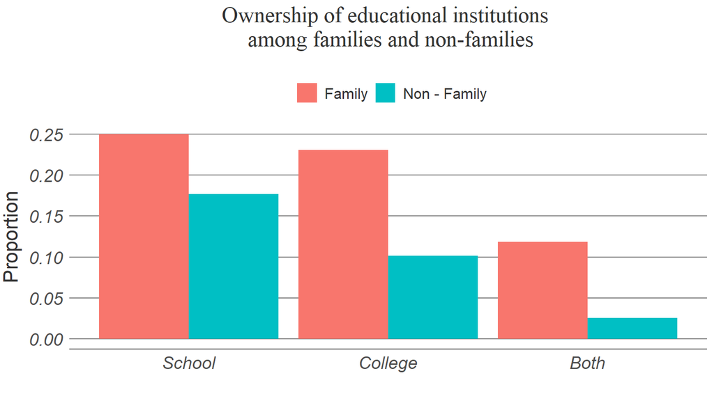

### 0.15.2 Political Experience

This depicts the ownership of the educational institutions with regards to political experience of the unique individuals.

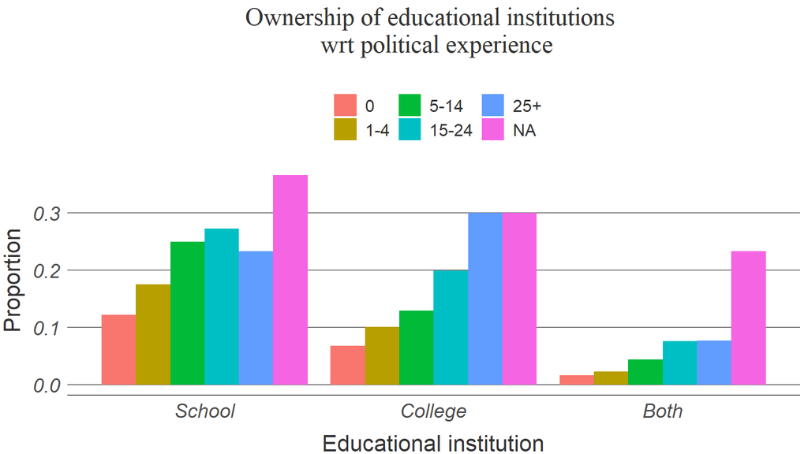

### 0.15.3 caste

Depicts the ownership of educational institutions with regards to the caste of the unique candidate.

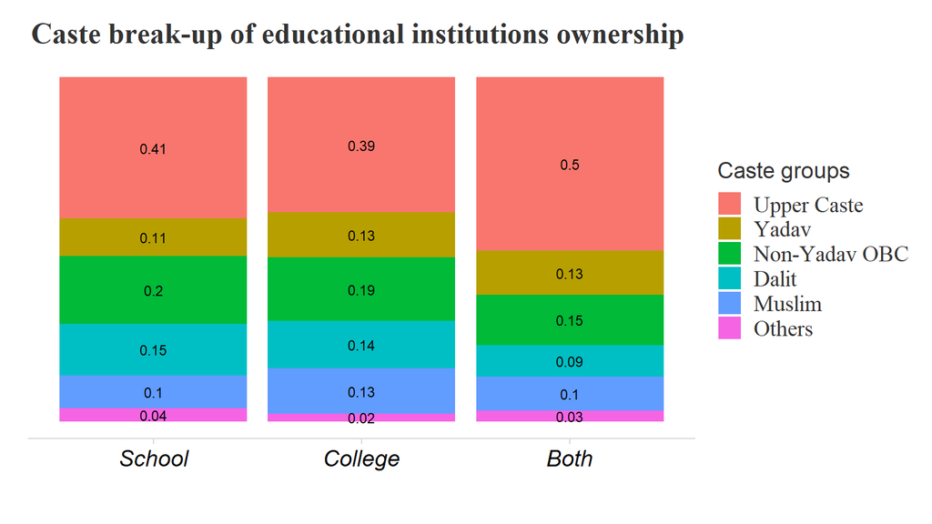

## 0.16 Industries

The dataset records the information regarding the candidate’s family’s ownership of industries in 12 different categories. For the ease if analysis we clubbed them to 5 categories.

[output not shown]

### 0.16.1 Family

#### 0.16.1.1 Average

Ownership of industries among families and non-families

Industry ownership

| Politician’s identity | Average number of ownersip |
| --- | --- |
| Family | 1.61 |
| Non-family | 0.67 |

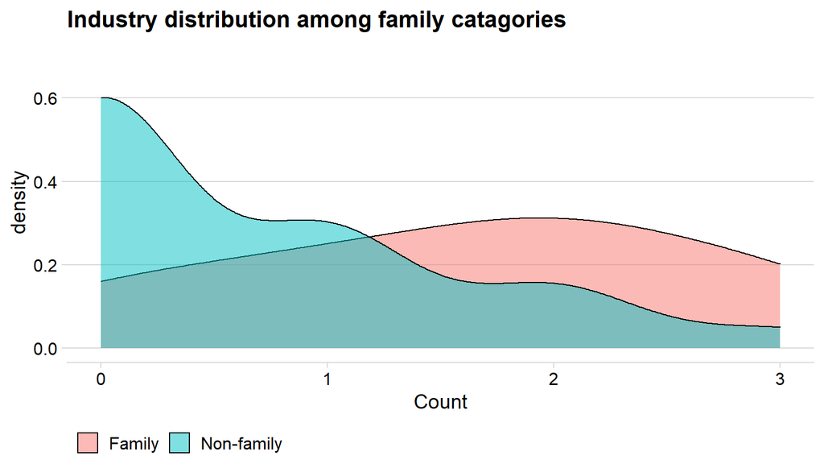

#### 0.16.1.2 Distribution

Industry distribution among families

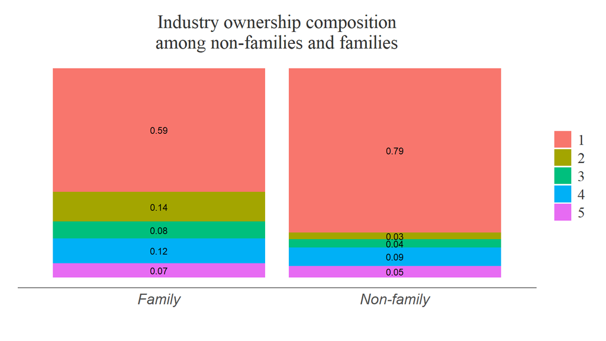

### 0.16.2 rent thick

#### 0.16.2.1 Average

Ownership of rent thick and non-rent thick industires with regards to the family type.

| Politician’s identity | rent-type | Proportion |
| --- | --- | --- |
| Family | non-rent-thick | 0.41 |
| Family | rent-thick | 0.59 |
| Non-family | non-rent-thick | 0.71 |
| Non-family | rent-thick | 0.29 |

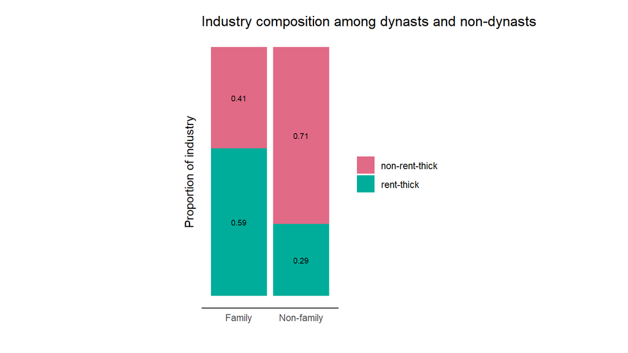

#### 0.16.2.2 Distribution

Ownership of industries among families and non-families with regards to the industry category.

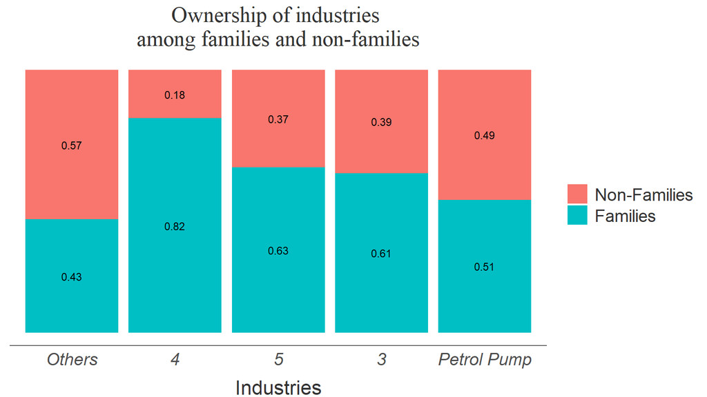

### 0.16.3 Political experience

Ownership of industries with regards to the candidate’s political experience

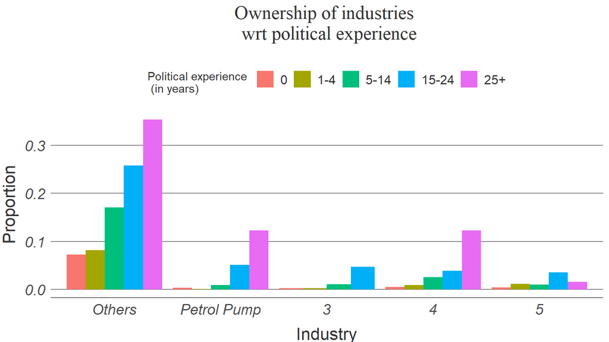

## 0.17 Political experience

### 0.17.1 Distribution - individuals

This tables shows the distribution of the unique individuals’ experience/

| Experience Categories | Count |
| --- | --- |
| 0 | 2145 |
| 1-5 | 1544 |
| 6-15 | 931 |
| 16+ | 247 |

### 0.17.2 Distribution - family

This table shows the distribution of the experience categories among the families and non-families.

| Experience Categories | Non-Families | Families |
| --- | --- | --- |
| 0 | 2127 | 18 |
| 1-5 | 1499 | 45 |
| 6-15 | 800 | 131 |
| 16+ | 119 | 128 |

### 0.17.3 caste

This shows the caste composition of the candidates with regards to their experience.

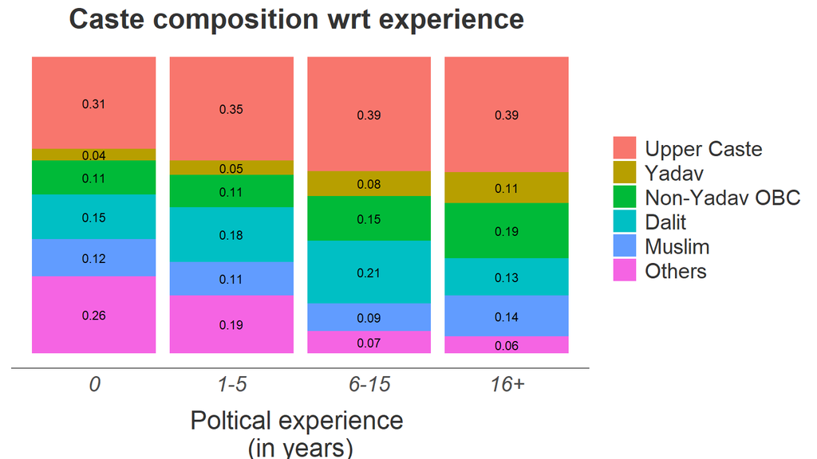

## 0.18 Caste

### 0.18.1 Individual composition

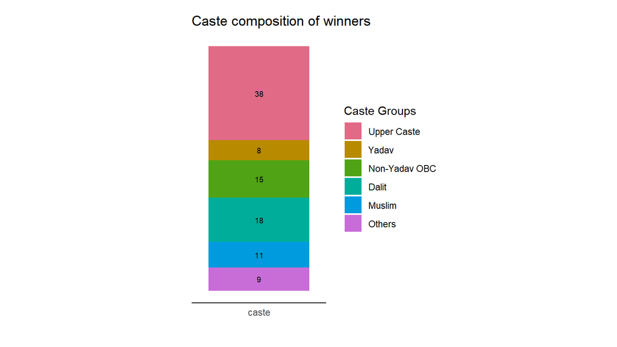

### 0.18.2 Family v/s non-family

- non-unqiue

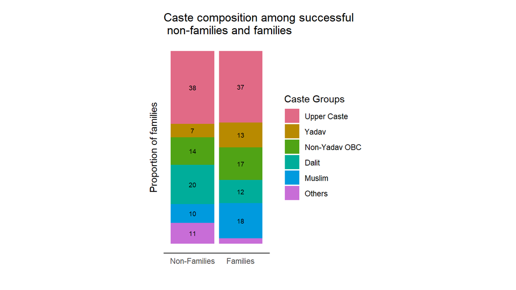

### 0.18.3 Year sections - caste composition

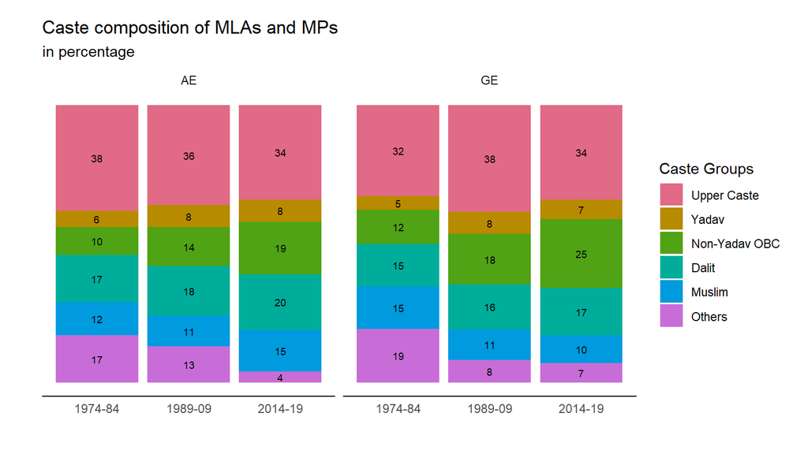

### 0.18.4 Caste composition - wrt year -Area chart

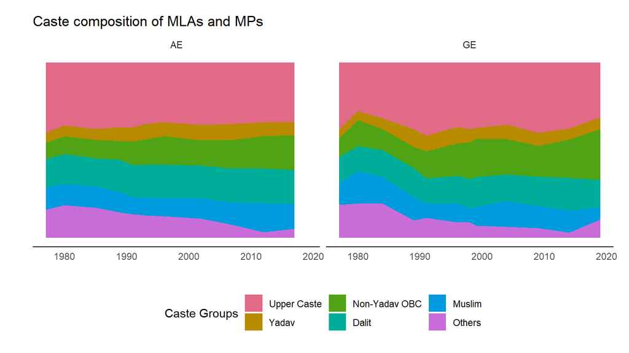